# Reanalysis of Muradoglu et al (2019, SRCD)

Marianna Zhang (marianna.zhang@stanford.edu)

January 09, 2019

## Introduction

Muradoglu et al 2019, Experiment 2 (social domain) found that a formal explanation boosts essentialism of gender compared to a control explanation, using a battery of essentialism measures.

This reanalysis examines if the effect holds with just one dependent measure of essentialism - mutability/innateness - to inform the study design of Marianna’s FYP.

## Data Formatting

```r
require("knitr")
### Data Preparation

#### Load Relevant Libraries and Functions
library(tidyverse)
#### Import data for analysis
data <- read_csv("MuradogluEtAl_2019_social_data.csv")
#### Initial data formatting
##### Rename questions
data <- data %>%
  rename(condition = formex) %>%
  mutate(question = recode(question,
         "1" = "stability_past",
         "2" = "stability_future",
         "3" = "innateness_switch",
         "4" = "innateness_stop",
         "5" = "inductivePotential"),
         condition = recode(condition,
          "0" = "control",
          "1" = "formal explanation"))
```

## Reproducing original results

```r
# Summary: essentialism by condition
data_summary <- data %>%
  group_by(condition) %>%
  summarize(avg=mean(response, na.rm=TRUE), sd=sd(response, na.rm=TRUE), n())
data_summary
```

```
## # A tibble: 2 x 4
##   condition            avg    sd `n()`
##   <chr>              <dbl> <dbl> <int>
## 1 control            0.590 0.475   960
## 2 formal explanation 0.645 0.463   900
```

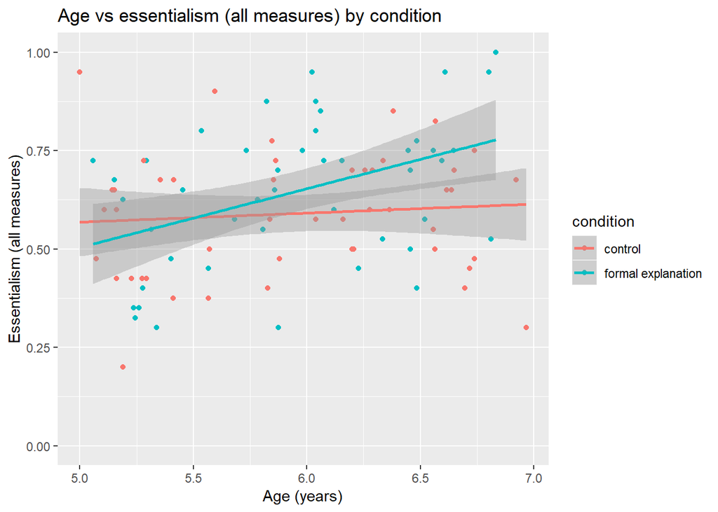

```r
# Essentialism per subject
data_subject <- data %>%
  group_by(subj, age, condition) %>%
  summarize(essentialism=mean(response, na.rm=TRUE), sd=sd(response, na.rm=TRUE))

# Plot of age vs essentialism by condition
ggplot(data_subject, aes(x = age, y = essentialism, color = condition)) +
  geom_point() +
  labs(x="Age (years)",
       y="Essentialism (all measures)") +
  geom_smooth(method = "lm") +
  # Essentialism compound measure is 0 to 1 scale
  scale_y_continuous(limits=c(0,1)) +
  ggtitle("Age vs essentialism (all measures) by condition")
```

```r
# ANOVA on essentialism between conditions with age as interaction
model = aov(essentialism ~ condition * age, data_subject)
summary(model)
```

```
##               Df Sum Sq Mean Sq F value Pr(>F)
## condition      1 0.0700 0.06999   2.571 0.1124
## age            1 0.1674 0.16745   6.150 0.0150 *
## condition:age  1 0.1122 0.11223   4.122 0.0453 *
## Residuals     89 2.4233 0.02723
## ---
## Signif. codes:  0 '***' 0.001 '**' 0.01 '*' 0.05 '.' 0.1 ' ' 1
```

As in the original analysis, the main effect of condition was not significant, p = .11.

The following original results were reproduced with a slightly larger p-values, which do not change their statistical significance. In the original analysis, the condition by age interaction was significant, p = .044. In this analysis, the condition by age interaction was significant, p = .045. In the original analysis, children gave more essentialist responses with age, p= .003. In this analysis, children gave more essentialist responses with age, p= .015.

```r
# Exploratory analysis by age
# essentialism between conditions, 6yo
data_subject_6yo <- data_subject %>%
  filter(age >= 6 & age < 7)
model_6yo = aov(essentialism ~ condition, data_subject_6yo)
summary(model_6yo)
```

```
##             Df Sum Sq Mean Sq F value Pr(>F)
## condition    1  0.139 0.13898   5.897 0.0193 *
## Residuals   44  1.037 0.02357
## ---
## Signif. codes:  0 '***' 0.001 '**' 0.01 '*' 0.05 '.' 0.1 ' ' 1
```

```r
# essentialism between conditions, 5yo
data_subject_5yo <- data_subject %>%
  filter(age < 6 & age >= 5)
model_5yo = aov(essentialism ~ condition, data_subject_5yo)
summary(model_5yo)
```

```
##             Df Sum Sq  Mean Sq F value Pr(>F)
## condition    1 0.0001 0.000108   0.003  0.953
## Residuals   45 1.4011 0.031136
```

The following original results were reproduced with a slightly different p-values, which do not change their statistical significance. In the original analysis, six-year-olds, but not 5-year olds, showed higher essentialism for properties introduced via formal explanations (ps = .011 and .999). In this analysis, six-year-olds, but not 5-year olds, showed higher essentialism for properties introduced via formal explanations (ps = .019 and .953).

## Reanalyzing with just innateness switch item

```r
# Filtering to innateness switch
data_innateness_switch <- data %>%
  filter(question == "innateness_switch")

# Summary: essentialism (innateness switch only) by condition
data_innateness_switch_summary <- data_innateness_switch %>%
  group_by(condition) %>%
  summarize(avg=mean(response, na.rm=TRUE), sd=sd(response, na.rm=TRUE), n())
data_innateness_switch_summary
```

```
## # A tibble: 2 x 4
##   condition            avg    sd `n()`
##   <chr>              <dbl> <dbl> <int>
## 1 control            0.604 0.490   192
## 2 formal explanation 0.639 0.482   180
```

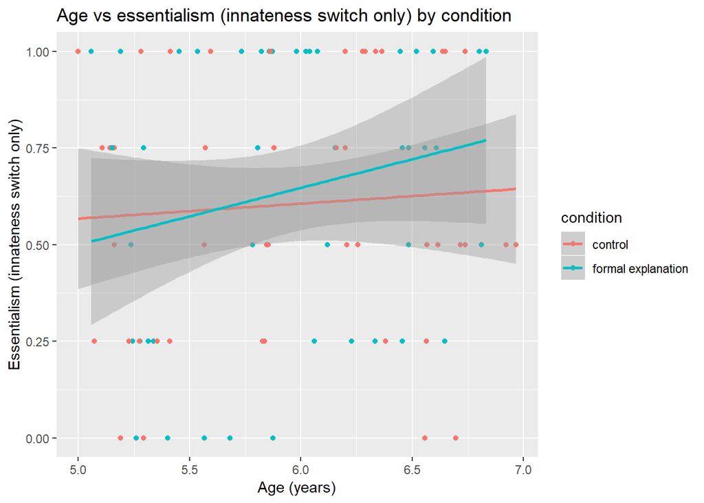

```r
# Essentialism (innateness switch only) per subject
data_innateness_switch_subject <- data_innateness_switch %>%
  group_by(subj, age, condition) %>%
  summarize(essentialism=mean(response, na.rm=TRUE), sd=sd(response, na.rm=TRUE))

# Plot of age vs essentialism by condition
ggplot(data_innateness_switch_subject, aes(x = age, y = essentialism, color = condition)) +
  geom_point() +
  labs(x="Age (years)",
       y="Essentialism (innateness switch only)") +
  geom_smooth(method = "lm") +
  # Essentialism compound measure is 0 to 1 scale
  scale_y_continuous(limits=c(0,1)) +
  ggtitle("Age vs essentialism (innateness switch only) by condition")
```

```r
# ANOVA on essentialism between conditions with age as interaction
model_innateness_switch = aov(essentialism ~ condition * age, data_innateness_switch_subject)
summary(model_innateness_switch)
```

```
##               Df Sum Sq Mean Sq F value Pr(>F)
## condition      1  0.028 0.02800   0.232  0.631
## age            1  0.207 0.20681   1.711  0.194
## condition:age  1  0.083 0.08304   0.687  0.409
## Residuals     89 10.759 0.12088
```

The main effect of condition is not significant, p = .63.

The condition by age interaction is no longer significant, p = .41. The main effect of age is also no longer significant, p= .19.

```r
# Analysis by age
# essentialism between conditions, 6yo
data_innateness_switch_subject_6yo <- data_innateness_switch_subject %>%
  filter(age >= 6 & age < 7)
model_innateness_switch_6yo = aov(essentialism ~ condition, data_innateness_switch_subject_6yo)
summary(model_innateness_switch_6yo)
```

```
##             Df Sum Sq Mean Sq F value Pr(>F)
## condition    1  0.027 0.02677   0.266  0.609
## Residuals   44  4.431 0.10071
```

```r
# essentialism between conditions, 5yo
data_innateness_switch_subject_5yo <- data_innateness_switch_subject %>%
  filter(age < 6 & age >= 5)
model_innateness_switch_5yo = aov(essentialism ~ condition, data_innateness_switch_subject_5yo)
summary(model_innateness_switch_5yo)
```

```
##             Df Sum Sq Mean Sq F value Pr(>F)
## condition    1  0.007 0.00677   0.048  0.827
## Residuals   45  6.302 0.14004
```

Neither 6-year-olds nor 5-year-olds showed higher essentialism ratings on the innateness switch task in the formal explanation condition compared to the control condition (ps = .61 and .83).